# Final Exam, Biostatistics, Fall 2021

2022/1/10

# Notes

1. You have three hours to complete this exam. Show all relevant work: partial credit will be given. Good luck!
2. Gather all your answers into an R Markdown (.Rmd) file. Then, upload this R Markdown file and its compiled html file to [e3](https://e3.nycu.edu.tw/) under the folder “final”.
3. If you have written part of your answers in the answer book, please also upload the scanned file of your written answers.
4. You can use “STAT-Wireless” to gain access to the internet.

Good luck!

# Questions

A study from the New England Journal of Medicine (2002;347:1999-2009) classified a series of 295 patients with primary breast carcinomas as having a poor prognosis signature or a good prognosis signature using their gene expression profiles. The dataset for the study `cancerdat.csv` can be downloaded from [e3](https://e3.nycu.edu.tw/) under the folder “final”. The variables of `cancerdat.csv` are described as follows:

[output not shown]

## Question 1

Define the expression level of `J00129` as
$$\mbox{Jexpr} = \left\{ \begin{array}{ll}
1 & \mbox{J00129} \leq -0.3 \mbox{ (low expression)} \\
2 & -0.3 < \mbox{J00129} \leq -0.1 \mbox{ (medium expression)} \\
3 & -0.1< \mbox{J00129} \mbox{ (high expression)}
\end{array} \right.$$
We want to study the association between the expression level of `J00129` (`Jexpr`) and distant metastasis (`EVENTmeta`). The data can be summarized as the following table:

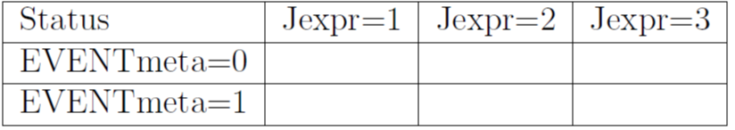

(10 points) Please first fill in the numbers in the above table. We are interested in knowing whether significant differences exist between any pair of expression levels. Perform multiple comparison procedures of Bonferroni, Holm and Benjamini-Hochberg to judge the significance.

## Question 2

Previous studies had shown that the lymph node status (`Posnodes`) may affect the relationship between `Jexpr` and `EVENTmeta`. We thus further organize the data as follows:

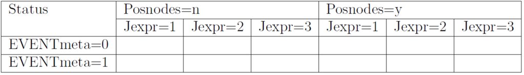

In this question, you will be asked to perform various logistic regressions for having distant metastasis (the response variable) on this data (the above summarized table).

1. (10 points) Is the lymph node status a confounder for the relationship between distant metastasis and `J00129` expression level? Justify your answer.
2. (10 points) Please first fill in the numbers in the above table. What is the saturated logistic regression model for this data? Use the numbers in the table to obtain the regression coefficients of the satureated model. Are your obtained coefficients the same as those from the computer outputs?
3. (10 points) Using the results from fitting the saturated model, provide a 95% confidence interval of the odds ratio for the association between distant metastasis and `J00129` expression level among lymph-node-negativers, comparing high versus medium expression levels.
4. (10 points) Do the interaction terms in the saturated model significantly improve the model fit to the data than the model with main effects only?
5. (10 points) Perform a series of goodness-of-fit tests to select the most parsimonious (with smallest number of coefficients) model among those that fit the data significantly well at significance level 0.05.

## Question 3

Now, we turn our attention to the survival probabilities.

1. (10 points) Based on the information provided in the description of variable `C1used`, create a new variable `Prognosis` with value 0 if having good-prognosis signature and value 1 if having poor-prognosis signature. Calculate the number of patients in the good-prognosis signature group and the number of patients in the poor-prognosis signature group.
2. (10 points) The study aimed to use variable `Prognosis` as the prediction of the other variable `EVENTmeta`. Provide the appropriate measure, hypothesis testing and conclusion to evaluate how good the prediction is.
3. (10 points) Provide the survival curves for both good-prognosis signature group and poor-prognosis signature group. Perform hypothesis testing to determine if there is a difference between two survival curves.
4. (10 points) Perform an analysis to examine whether two prognosis groups have different hazard rates. Be sure to adjust for the potential confounding effects of lymph node status (`Posnodes`) and estrogen-receptor status (`ESR1`).